# Assignment-2

January 28, 2017

**Data: In this problem set we will use the nycflights13 R package that contains data for all flights that departed NYC (i.e. JFK, LGA or EWR) in 2013.**

```r
install.packages("nycflights13", repos = "http://cran.us.r-project.org") #install package
library(nycflights13)                                                    # load data package
data(flights)                                                            # load data on flights
library(dplyr)                                                           # load dplyr package
#understanding the data
summary(flights)
```

```
##       year          month             day           dep_time
##  Min.   :2013   Min.   : 1.000   Min.   : 1.00   Min.   :   1
##  1st Qu.:2013   1st Qu.: 4.000   1st Qu.: 8.00   1st Qu.: 907
##  Median :2013   Median : 7.000   Median :16.00   Median :1401
##  Mean   :2013   Mean   : 6.549   Mean   :15.71   Mean   :1349
##  3rd Qu.:2013   3rd Qu.:10.000   3rd Qu.:23.00   3rd Qu.:1744
##  Max.   :2013   Max.   :12.000   Max.   :31.00   Max.   :2400
##                                                  NA's   :8255
##  sched_dep_time   dep_delay          arr_time    sched_arr_time
##  Min.   : 106   Min.   : -43.00   Min.   :   1   Min.   :   1
##  1st Qu.: 906   1st Qu.:  -5.00   1st Qu.:1104   1st Qu.:1124
##  Median :1359   Median :  -2.00   Median :1535   Median :1556
##  Mean   :1344   Mean   :  12.64   Mean   :1502   Mean   :1536
##  3rd Qu.:1729   3rd Qu.:  11.00   3rd Qu.:1940   3rd Qu.:1945
##  Max.   :2359   Max.   :1301.00   Max.   :2400   Max.   :2359
##                 NA's   :8255      NA's   :8713
##    arr_delay          carrier              flight       tailnum
##  Min.   : -86.000   Length:336776      Min.   :   1   Length:336776
##  1st Qu.: -17.000   Class :character   1st Qu.: 553   Class :character
##  Median :  -5.000   Mode  :character   Median :1496   Mode  :character
##  Mean   :   6.895                      Mean   :1972
##  3rd Qu.:  14.000                      3rd Qu.:3465
##  Max.   :1272.000                      Max.   :8500
##  NA's   :9430
##     origin              dest              air_time        distance
##  Length:336776      Length:336776      Min.   : 20.0   Min.   :  17
##  Class :character   Class :character   1st Qu.: 82.0   1st Qu.: 502
##  Mode  :character   Mode  :character   Median :129.0   Median : 872
##                                        Mean   :150.7   Mean   :1040
##                                        3rd Qu.:192.0   3rd Qu.:1389
##                                        Max.   :695.0   Max.   :4983
##                                        NA's   :9430
##       hour           minute        time_hour
##  Min.   : 1.00   Min.   : 0.00   Min.   :2013-01-01 05:00:00
##  1st Qu.: 9.00   1st Qu.: 8.00   1st Qu.:2013-04-04 13:00:00
##  Median :13.00   Median :29.00   Median :2013-07-03 10:00:00
##  Mean   :13.18   Mean   :26.23   Mean   :2013-07-03 05:02:36
##  3rd Qu.:17.00   3rd Qu.:44.00   3rd Qu.:2013-10-01 07:00:00
##  Max.   :23.00   Max.   :59.00   Max.   :2013-12-31 23:00:00
##
```

```r
attach(flights)
unique(carrier)
```

```
##  [1] "UA" "AA" "B6" "DL" "EV" "MQ" "US" "WN" "VX" "FL" "AS" "9E" "F9" "HA"
## [15] "YV" "OO"
```

```r
unique(origin)
```

```
## [1] "EWR" "LGA" "JFK"
```

```r
unique(dest)
```

```
##   [1] "IAH" "MIA" "BQN" "ATL" "ORD" "FLL" "IAD" "MCO" "PBI" "TPA" "LAX"
##  [12] "SFO" "DFW" "BOS" "LAS" "MSP" "DTW" "RSW" "SJU" "PHX" "BWI" "CLT"
##  [23] "BUF" "DEN" "SNA" "MSY" "SLC" "XNA" "MKE" "SEA" "ROC" "SYR" "SRQ"
##  [34] "RDU" "CMH" "JAX" "CHS" "MEM" "PIT" "SAN" "DCA" "CLE" "STL" "MYR"
##  [45] "JAC" "MDW" "HNL" "BNA" "AUS" "BTV" "PHL" "STT" "EGE" "AVL" "PWM"
##  [56] "IND" "SAV" "CAK" "HOU" "LGB" "DAY" "ALB" "BDL" "MHT" "MSN" "GSO"
##  [67] "CVG" "BUR" "RIC" "GSP" "GRR" "MCI" "ORF" "SAT" "SDF" "PDX" "SJC"
##  [78] "OMA" "CRW" "OAK" "SMF" "TUL" "TYS" "OKC" "PVD" "DSM" "PSE" "BHM"
##  [89] "CAE" "HDN" "BZN" "MTJ" "EYW" "PSP" "ACK" "BGR" "ABQ" "ILM" "MVY"
## [100] "SBN" "LEX" "CHO" "TVC" "ANC" "LGA"
```

```r
detach(flights)
```

**1. Let’s explore flights from NYC to Seattle. Use the flights dataset to answer the following questions. a) (2 pt) How many flights were there to and from NYC in 2013?**

Number of flights from NYC:

```r
unique(flights$origin)           # Validate all the flights originate from NYC
```

```
## [1] "EWR" "LGA" "JFK"
```

```r
nrow(flights)                    # Number of flights from NYC is equal to the number of rows in the dataframe
```

```
## [1] 336776
```

Number of flights to NYC:

```r
NYC_airports <- c("JFK","LGA","EWR")                                                           #3 airports in NYC in a variable to help with pattern matching
flight_to_NYC <- grep(paste(NYC_airports,collapse="|"),flights$dest, ignore.case=TRUE, value=TRUE) #finding the rows where dest in ("JFK","EWR","LGA")
length(flight_to_NYC)                                                                              #Length of vector to determine no. of flights to NYC
```

```
## [1] 1
```

**b) (2 pt) How many flights were there from NYC airports to Seattle (SEA) in 2013?**

```r
flights_to_Sea <- subset(flights, flights$dest =="SEA")     #subset the flights dataframe for dest="SEA"
nrow(flights_to_Sea)
```

```
## [1] 3923
```

**c) (2 pt) How many airlines fly from NYC to Seattle? Hint: look at the function unique()**

```r
unique(flights_to_Sea[,"carrier"])                      #identify unique carriers that fly from NYC to SEA
```

```
## # A tibble: 5 × 1
##   carrier
##     <chr>
## 1      AS
## 2      DL
## 3      UA
## 4      B6
## 5      AA
```

```r
nrow(unique(flights_to_Sea[,"carrier"]))
```

```
## [1] 5
```

**d) (2 pt) What is the average arrival delay for flights from NYC to Seattle? Hint: if there are missing values in the vector you want the mean of, you have to remove them. Try the following: mean(c(1,2,3,NA)) and mean(c(1,2,3,NA), na.rm=T)**

```r
levels(as.factor(is.na(flights_to_Sea$arr_delay)))  #identify the presence of missing values in data set
```

```
## [1] "FALSE" "TRUE"
```

```r
mean(flights_to_Sea$arr_delay, na.rm=T)             #calculate mean ignoring NA values
```

```
## [1] -1.099099
```

**2. Flights are often delayed. Consider the following questions exploring delay patterns.** **a) (4 pt) What is the mean arrival delay time? What is the median arrival delay time?** Mean arrival delay time:

```r
mean(flights$arr_delay, na.rm=T)
```

```
## [1] 6.895377
```

Median arrival delay time:

```r
median(flights$arr_delay, na.rm=T)
```

```
## [1] -5
```

**b) (2 pt) What does a negative arrival delay mean?** It implies that the flights are arriving before the scheduled time.

**c) (4 pt) Plot a histogram of arrival delay times. Does the answers you obtained in (a) consistent with the shape of the delay time distribution?**

[figure not shown]

```r
hist(flights$arr_delay, breaks=100, xaxt="n")
axis(side=1, at=seq(-100,500,5))
abline(v=mean(flights$arr_delay, na.rm=T), col = 3)
abline(v=median(flights$arr_delay, na.rm=T), col = 4)
legend("topright", cex=0.70, legend=c("Median","Mean"), lty = c(1,1), lwd = c(1,1), col = c(3,4))
```

Yes, the answers obtained in (a) are consistent with the shape of the delay time distribution. Ideally, in a right skewed distribution, median < mean

**d) (4 pt) Is there seasonality in departure delays? Try by(flights$dep_delay, flights$month, function(x) mean(x, na.rm=T)) and describe what patterns you see. Is there a best month to leave New York? A worst? Why might this be?**

```r
x <- by(flights$dep_delay, flights$month, function(x) mean(x, na.rm=T))
x
```

```
## flights$month: 1
## [1] 10.03667
## --------------------------------------------------------
## flights$month: 2
## [1] 10.81684
## --------------------------------------------------------
## flights$month: 3
## [1] 13.22708
## --------------------------------------------------------
## flights$month: 4
## [1] 13.93804
## --------------------------------------------------------
## flights$month: 5
## [1] 12.98686
## --------------------------------------------------------
## flights$month: 6
## [1] 20.84633
## --------------------------------------------------------
## flights$month: 7
## [1] 21.72779
## --------------------------------------------------------
## flights$month: 8
## [1] 12.61104
## --------------------------------------------------------
## flights$month: 9
## [1] 6.722476
## --------------------------------------------------------
## flights$month: 10
## [1] 6.243988
## --------------------------------------------------------
## flights$month: 11
## [1] 5.435362
## --------------------------------------------------------
## flights$month: 12
## [1] 16.57669
```

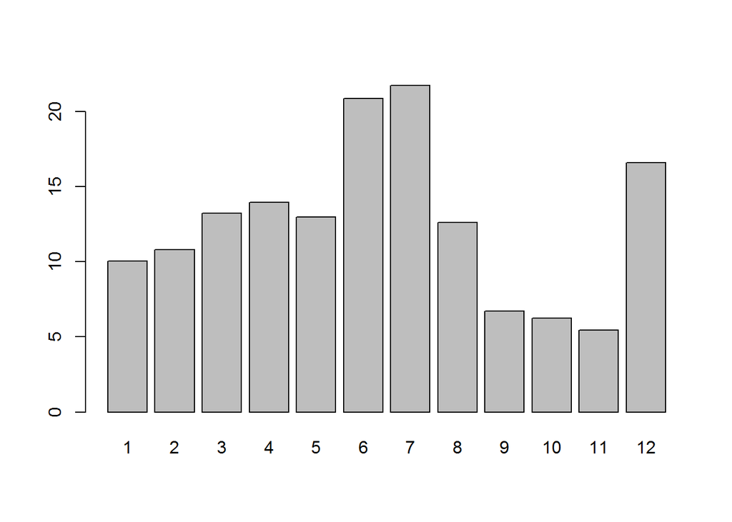

```r
barplot(x)
```

The mean departure varies by month. The mean departure delay times steadily increase from January to July, except for a dip experienced in the month of May. Post July, the average departure delay times decrease until the holiday season in Dec which has a high spike in departure delay time.

The best month to leave New York is November, closely followed by October and Septemeber. This can be due to the off-season period. i.e. the air traffic is limited as the demand for travelling is considerably less during this season. The worst month to leave New York is July closely followed by June and December due to the following reasons:

The average departure delays are high during the summer holidays (June - July) and the winter holidays (Dec). 1)NYC is an important connecting departure hub to Europe which is a popular summer holiday destinations. Air traffic can cause departure delays 2)The weather conditions in Dec such as snow causes flight delays.

**3. EDA** **a) (4 pt) Plot a histogram of the total air flight time with 100 breaks. (look at the help for hist()). How many peaks do you see in this distribution? What is an explanation for this?**

```r
mean(flights$air_time,na.rm = T)
```

```
## [1] 150.6865
```

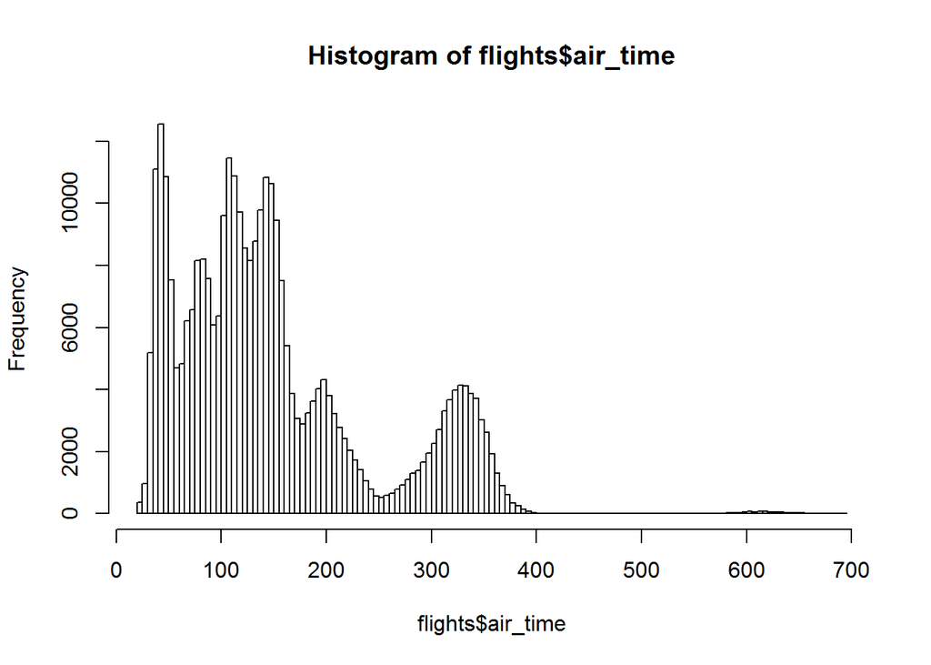

```r
hist(flights$air_time, breaks=100)
```

There are 7 peaks in this distribution with a prominent peaks around 50 minutes and between 100-200 minutes total air flight time. A possible reason for this is that the count of flights departing from NYC to destinations in the total air time range of around 50 minutes is high. For example, total number of flights to Boston in the 2013 were 15508 with a mean air time of 38 minutes. As seen in the top ten destinations below based on number of flights in 2013, 5/10 flights have a total air time between 100-200 minutes. The high number of short flights is due to the fact that NYC is a connecting hub and a popular point of arrival to the US.

```r
flights_per_dest <- flights %>%
  group_by(dest) %>%
  summarise(count = n())
top_dest <- arrange(flights_per_dest, desc(count))
top_dest
```

```
## # A tibble: 105 × 2
##     dest count
##    <chr> <int>
## 1    ORD 17283
## 2    ATL 17215
## 3    LAX 16174
## 4    BOS 15508
## 5    MCO 14082
## 6    CLT 14064
## 7    SFO 13331
## 8    FLL 12055
## 9    MIA 11728
## 10   DCA  9705
## # ... with 95 more rows
```

```r
mean_time_per_dest <- flights %>%
  group_by(dest) %>%
  summarise(mean_time = mean(air_time, na.rm=T))
mean_time_per_dest <- arrange(mean_time_per_dest,mean_time)
head(mean_time_per_dest,15)
```

```
## # A tibble: 15 × 2
##     dest mean_time
##    <chr>     <dbl>
## 1    BDL  25.46602
## 2    ALB  31.78708
## 3    PVD  32.66760
## 4    PHL  33.17132
## 5    MVY  36.31905
## 6    BWI  38.49970
## 7    MHT  38.50858
## 8    BOS  38.95300
## 9    ACK  42.06818
## 10   SYR  43.03984
## 11   DCA  45.85655
## 12   BTV  46.44980
## 13   PWM  47.69187
## 14   IAD  47.82779
## 15   ROC  49.90925
```

```r
a <- merge(top_dest,mean_time_per_dest,by="dest")
head(arrange(a,desc(count)),10)
```

```
##    dest count mean_time
## 1   ORD 17283 115.58813
## 2   ATL 17215 112.93045
## 3   LAX 16174 328.12118
## 4   BOS 15508  38.95300
## 5   MCO 14082 134.77347
## 6   CLT 14064  86.15072
## 7   SFO 13331 345.68314
## 8   FLL 12055 152.24603
## 9   MIA 11728 153.13784
## 10  DCA  9705  45.85655
```

**b) (4 pt) What time of day do flights most commonly depart? Why might there be two most popular times of day to depart?**

```r
time_of_day <- flights %>%
  group_by(sched_dep_time) %>%
  summarise(count = n())%>%
  arrange(desc(count))

time_of_day
```

```
## # A tibble: 1,021 × 2
##    sched_dep_time count
##             <int> <int>
## 1             600  7016
## 2             700  4900
## 3             630  4770
## 4             900  4766
## 5            1200  4624
## 6            1700  4526
## 7            1600  4098
## 8             800  3926
## 9            1300  3689
## 10           1900  3653
## # ... with 1,011 more rows
```

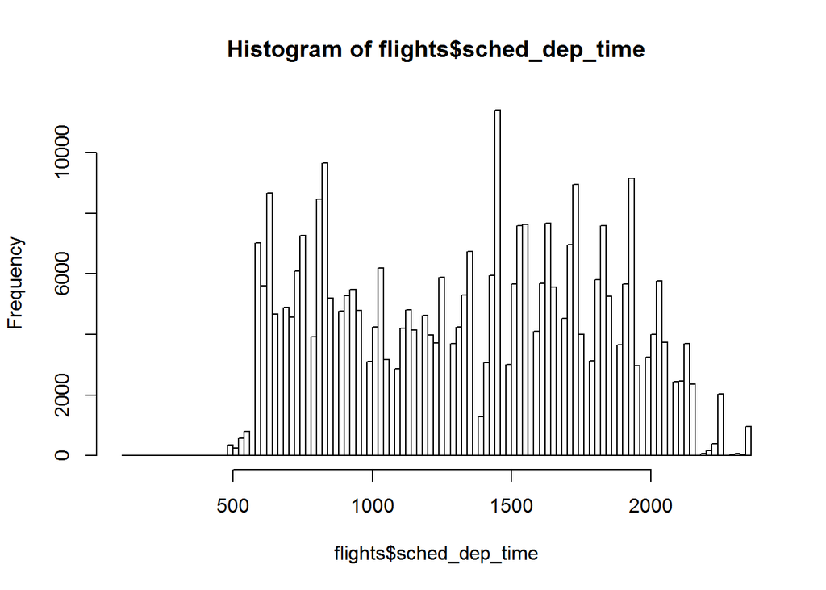

```r
hist(flights$sched_dep_time, breaks=100)
```

```r
morn_flights <- subset(flights, flights$hour==6)
avg_dep_delay_morn <- mean(morn_flights$dep_delay, na.rm=T)
cat('avg_dep_delay_morn = ',avg_dep_delay_morn)
```

```
## avg_dep_delay_morn =  1.642796
```

```r
cat("\n")
```

```r
avg_dep_delay <- mean(flights$dep_delay, na.rm=T)
cat('avg_dep_delay = ',avg_dep_delay)
```

```
## avg_dep_delay =  12.63907
```

```r
cat("\n")
```

```r
avg_arr_delay_morn <- mean(morn_flights$arr_delay, na.rm=T)
cat('avg_arr_delay_morn = ',avg_arr_delay_morn)
```

```
## avg_arr_delay_morn =  -3.384485
```

```r
cat("\n")
```

```r
avg_arr_delay <- mean(flights$arr_delay, na.rm=T)
cat('avg_arr_delay = ',avg_arr_delay)
```

```
## avg_arr_delay =  6.895377
```

```r
cat("\n")
```

Flights departing in the morning around 6 am have a considerably less departure delay than the mean delay throughout the day. Additionally, morning flights departing from NYC are preferred are they allow for more time during the day at the destinations which are in different time-zones.

Similarly afternoon flights are popular as the departure time is convenient.

**c) (4 pt) Plot a box plot of departure delays and hour of departure. What pattern do you see? What is an explanation for this?**

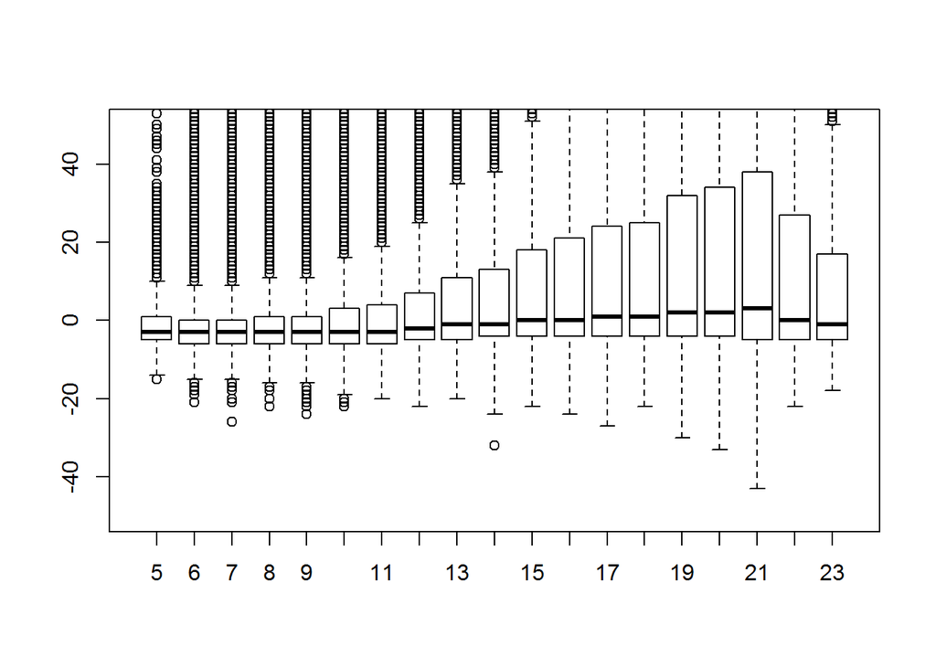

```r
boxplot(flights$dep_delay~flights$hour, ylim=c(-50,50))
```

The boxplot shows that the median of the departure delays across the hours is close to 0. However, the IQR is prominently higher after the hours 1400 which implies that the departure delays times are much more than those observed in the morning i.e the amount of time by which the flights are delayed is much more after 1400 than in the early hours of the day.

**4. (10 pt) Develop one research question you can address using the nycflights2013 dataset. Provide two visualizations to support your exploration of this question. Discuss what you find.**

```r
flights$total_delay <- flights$dep_delay + flights$arr_delay

total_delay <- flights %>%
  group_by(dest) %>%
  summarise(count=n(), mean_delay = mean(total_delay, na.rm=T))

top_total_delay <- arrange(filter(total_delay, count>10000),desc(mean_delay))

top_total_delay
```

```
## # A tibble: 9 × 3
##    dest count mean_delay
##   <chr> <int>      <dbl>
## 1   ATL 17215  23.725248
## 2   FLL 12055  20.765907
## 3   ORD 17283  19.309429
## 4   MCO 14082  16.719983
## 5   CLT 14064  16.556750
## 6   SFO 13331  15.411599
## 7   BOS 15508  11.576421
## 8   LAX 16174   9.898353
## 9   MIA 11728   9.167860
```

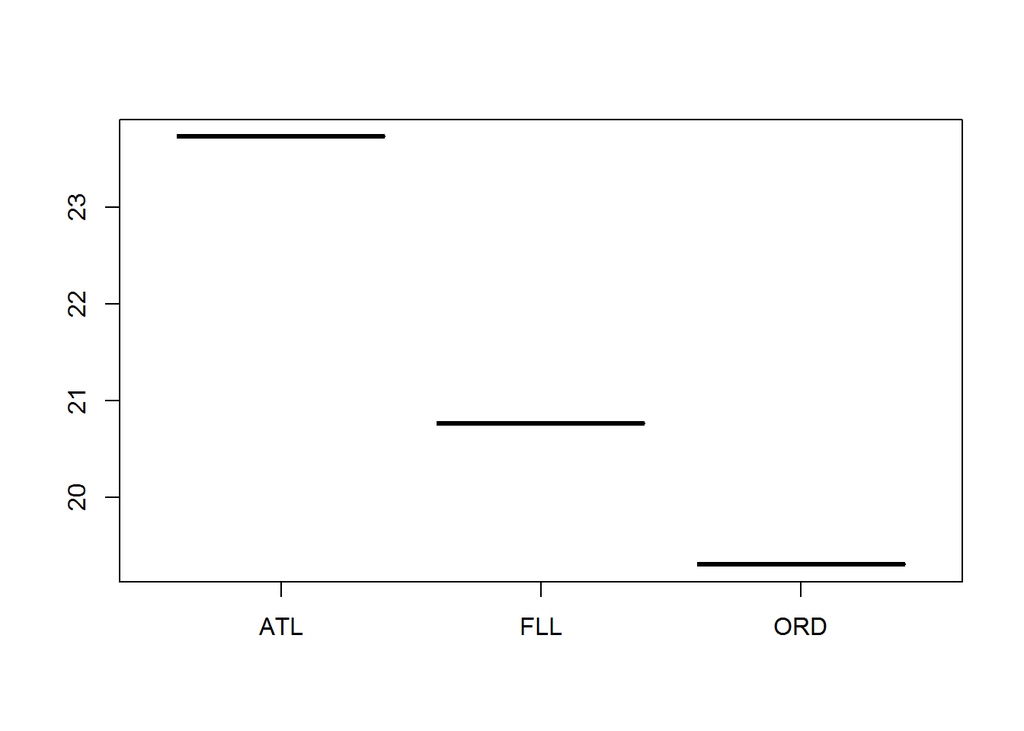

```r
v <- head(top_total_delay,3)

v$dest <- as.factor(v$dest)

plot(v$dest,v$mean_delay)
```

```r
#target_dest <- c()
carriers_dest1 <- filter(flights, grepl('ATL',dest))

total_delay1 <- carriers_dest1 %>%
  group_by(carrier) %>%
  summarise(mean_delay = mean(total_delay, na.rm=T))

total_delay1<- arrange(total_delay1, desc(mean_delay))
total_delay1
```

```
## # A tibble: 7 × 2
##   carrier mean_delay
##     <chr>      <dbl>
## 1      EV  41.899155
## 2      FL  39.013169
## 3      UA  25.166667
## 4      MQ  23.367338
## 5      DL  17.773919
## 6      WN   9.241379
## 7      9E   1.839286
```

```r
carriers_dest2 <- filter(flights, grepl('FLL',dest))

total_delay2 <- carriers_dest2 %>%
  group_by(carrier) %>%
  summarise(mean_delay = mean(total_delay, na.rm=T))

total_delay2<- arrange(total_delay2, desc(mean_delay))
total_delay2
```

```
## # A tibble: 4 × 2
##   carrier mean_delay
##     <chr>      <dbl>
## 1      B6 26.5004640
## 2      UA 17.8661616
## 3      DL 11.5410292
## 4      AA  0.3240223
```

```r
carriers_dest3 <- filter(flights, grepl('ORD',dest))

total_delay3 <- carriers_dest3 %>%
  group_by(carrier) %>%
  summarise(mean_delay = mean(total_delay, na.rm=T))

total_delay3<- arrange(total_delay3, desc(mean_delay))
total_delay3
```

```
## # A tibble: 7 × 2
##   carrier mean_delay
##     <chr>      <dbl>
## 1      OO 174.000000
## 2      9E  36.484756
## 3      MQ  33.619456
## 4      EV  33.000000
## 5      B6  32.596413
## 6      UA  19.909698
## 7      AA   8.534382
```

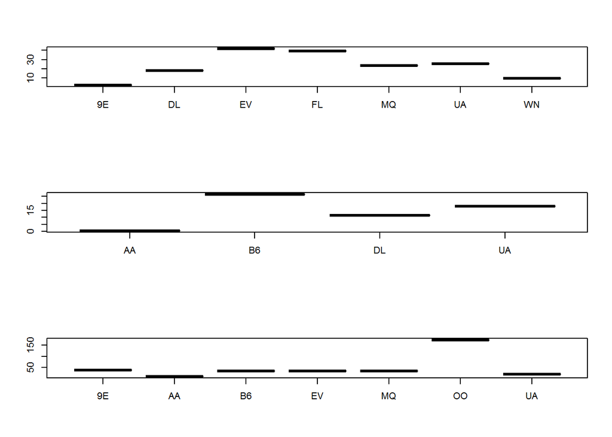

```r
total_delay1$carrier <- as.factor(total_delay1$carrier)
total_delay2$carrier <- as.factor(total_delay2$carrier)
total_delay3$carrier <- as.factor(total_delay3$carrier)

par(mfrow=c(3,1))
plot(total_delay1$carrier, total_delay1$mean_delay)
plot(total_delay2$carrier, total_delay2$mean_delay,pch=2)
plot(total_delay3$carrier, total_delay3$mean_delay,pch=8)
```